# R Notebook - HSPF Analysis

Analysis of HSPF (comparison of NREL 9 HSPF to 14 HSPF)

```r
library(arrow)
library(dplyr)
library(tidyr)
library(data.table)
library(ggplot2)
library(knitr)
library(kableExtra)

# Load baseline, and scenarios 3 (min efficiency w/ elec resistance backup) and 4 (hi efficiency w/ elec resistance backup)
urls <- c(
  'https://oedi-data-lake.s3.amazonaws.com/nrel-pds-building-stock/end-use-load-profiles-for-us-building-stock/2022/resstock_tmy3_release_1/metadata_and_annual_results/national/parquet/baseline_metadata_and_annual_results.parquet',
  'https://oedi-data-lake.s3.amazonaws.com/nrel-pds-building-stock/end-use-load-profiles-for-us-building-stock/2022/resstock_tmy3_release_1/metadata_and_annual_results/national/parquet/upgrade03_metadata_and_annual_results.parquet',
  'https://oedi-data-lake.s3.amazonaws.com/nrel-pds-building-stock/end-use-load-profiles-for-us-building-stock/2022/resstock_tmy3_release_1/metadata_and_annual_results/national/parquet/upgrade04_metadata_and_annual_results.parquet'
)

destinations <- c(
  'baseline_metadata_and_annual_results.parquet',
  'upgrade03_metadata_and_annual_results.parquet',
  'upgrade04_metadata_and_annual_results.parquet'
)

temp_paths = c()

for(i in seq_along(urls)) {
  temp_path = file.path(tempdir(), destinations[i])
  download.file(urls[i], temp_path, mode='wb')
  temp_paths[i] = temp_path
}

baseline <- read_parquet(temp_paths[1]) %>% filter(in.geometry_building_type_recs=='Single-Family Detached')
up03 <- read_parquet(temp_paths[2]) %>% filter(in.geometry_building_type_recs=='Single-Family Detached')
up04 <- read_parquet(temp_paths[3]) %>% filter(in.geometry_building_type_recs=='Single-Family Detached')

upgrades <- list(baseline, up03, up04)
data <- bind_rows(upgrades)
```

Now that we’ve loaded in the ResStock files, we’ll incorporate utility prices, and we’ll also calculate our new scenarios 11 and 12 which reflect min efficiency with existing fuel backup (11) and hi efficiency with existing fuel backup (12)

```r
# Read in utility prices
util <- fread('https://raw.githubusercontent.com/pilch/pilch.github.io/master/utility_prices.csv')

# Convert util price data from wide to long
util_long <- util %>% gather("month","price",-c(in.state,in.heating_fuel)) %>%
  mutate(price=as.numeric(price))
# Add national averages as a column so that we can fill in NAs
nat_sum <- util_long %>%
  filter(!is.na(price)) %>%
  group_by(in.heating_fuel,month) %>%
  summarize(avg = mean(price))

# Merge the national monthly averages back in, and set the price to the
# national average if na, then drop the avg column to get our final price dataset
util_long2 <- util_long %>% left_join(nat_sum) %>%
  mutate(price = case_when(is.na(price) ~ avg,
                           !is.na(price) ~ price)) %>%
  select(-avg)

# Everything is currently in units as reported by EIA, so we need to convert
# Electricity = cents per KWH, need to be converted to dollars per KWH (divide by 100)
# Natural gas = dollars per thousand cubic feet, convert to dollars per KWH
# Fuel oil = dollars per gallon, convert to dollars per KWH
# Propane = dollars per gallon, convert to dollars per KWH
conversion <- data.frame(in.heating_fuel = c(
  'Electricity',
  'Natural Gas',
  'Fuel Oil',
  'Propane'
),
priceperkwh = c(
  1/100,
  1/(10.39*29.3001),
  1/(1.37380952*29.308),
  1/(.91452*29.308)
)
)

# Merge with the price conversion data to cast everything in dollars per kwh
util_long3 <- util_long2 %>% left_join(conversion) %>%
  mutate(price = price * priceperkwh) %>%
  select(-priceperkwh) %>%
  mutate(month = as.Date(month,"%m/%d/%Y"))

# Pick which timeframe to use for the analysis - we'll use average heating season (Oct - Mar)
# since Oct 2018
# Note: There are 0s in the EIA data for some months, so we filter for 0 values
# so that they don't distort the averages. Also convert long to wide so that
# each home can have all 4 relevant energy prices
util_merge <- util_long3 %>%
  mutate(monthnum = month(month)) %>%
  filter(month >= '2018-10-01', price != 0, monthnum %in% c(10,11,12,1,2,3)) %>%
  group_by(in.state,in.heating_fuel) %>%
  summarize(price=mean(price,na.rm=TRUE)) %>%
  spread(in.heating_fuel, price)
colnames(util_merge) <- c('in.state','price_electricity','price_fuel_oil','price_natural_gas','price_propane')


# Map furnace efficiencies to numeric values
furnace_effic <- data.frame(in.hvac_heating_efficiency = c(
  "ASHP, SEER 13, 7.7 HSPF",
  "ASHP, SEER 15, 8.5 HSPF",
  "ASHP, SEER 10, 6.2 HSPF",
  "Electric Baseboard, 100% Efficiency",
  "Electric Boiler, 100% AFUE",
  "Electric Furnace, 100% AFUE",
  "Electric Wall Furnace, 100% AFUE",
  "Fuel Boiler, 76% AFUE",
  "Fuel Boiler, 80% AFUE",
  "Fuel Boiler, 90% AFUE",
  "Fuel Furnace, 76% AFUE",
  "Fuel Furnace, 80% AFUE",
  "Fuel Furnace, 92.5% AFUE",
  "Fuel Wall/Floor Furnace, 60% AFUE",
  "Fuel Wall/Floor Furnace, 68% AFUE",
  "Fuel Boiler, 76% AFUE",
  "Fuel Boiler, 80% AFUE",
  "Fuel Furnace, 60% AFUE",
  "Fuel Furnace, 76% AFUE",
  "Fuel Furnace, 80% AFUE",
  "Fuel Furnace, 92.5% AFUE",
  "Fuel Wall/Floor Furnace, 60% AFUE",
  "Fuel Wall/Floor Furnace, 68% AFUE",
  "None",
  "Other",
  "Fuel Boiler, 76% AFUE",
  "Fuel Boiler, 80% AFUE",
  "Fuel Boiler, 90% AFUE",
  "Fuel Furnace, 60% AFUE",
  "Fuel Furnace, 76% AFUE",
  "Fuel Furnace, 80% AFUE",
  "Fuel Furnace, 92.5% AFUE",
  "Fuel Wall/Floor Furnace, 60% AFUE",
  "Fuel Wall/Floor Furnace, 68% AFUE"
), heating_effic_def = c(
  1.000,
  1.000,
  1.000,
  1.000,
  1.000,
  1.000,
  1.000,
  0.760,
  0.800,
  0.900,
  0.760,
  0.800,
  0.925,
  0.600,
  0.680,
  0.760,
  0.800,
  0.600,
  0.760,
  0.800,
  0.925,
  0.600,
  0.680,
  1.000,
  1.000,
  0.760,
  0.800,
  0.900,
  0.600,
  0.760,
  0.800,
  0.925,
  0.600,
  0.680
))

furnace_effic <- furnace_effic %>% distinct(in.hvac_heating_efficiency,heating_effic_def)

data_p2 <- data %>% left_join(furnace_effic)

# Calculate a new high-efficiency, existing fuel backup scenario
# Assumes heat pump will consume the same amount of electrical input
# as upgrade 03, but instead of elec resistance backup, the backup will be
# the existing heating system. Specifically, take electricity.heating_hp_bkup
# from upgrade 03, assume 100% efficiency, so then divide this backup energy by
# the efficiency of their existing furnace to get input. Then do the same thing
# for upgrade 04, and we'll call i upgrade 12
data_p3a <- data_p2 %>%
  filter(upgrade==3) %>%
  mutate(backup_input_kwh = out.electricity.heating_hp_bkup.energy_consumption.kwh / heating_effic_def) %>%
  mutate(deduct_from_total = -out.electricity.heating_hp_bkup.energy_consumption.kwh) %>%
  mutate(out.electricity.heating_hp_bkup.energy_consumption.kwh = 0) %>%
  mutate(
    out.electricity.heating_hp_bkup.energy_consumption.kwh = if_else(in.heating_fuel == 'Electricity',
                                                                     backup_input_kwh,0),
    out.propane.heating_hp_bkup.energy_consumption.kwh = if_else(in.heating_fuel == 'Propane',
                                                                 backup_input_kwh,0),
    out.natural_gas.heating_hp_bkup.energy_consumption.kwh = if_else(in.heating_fuel == 'Natural Gas',
                                                                     backup_input_kwh,0),
    out.fuel_oil.heating_hp_bkup.energy_consumption.kwh = if_else(in.heating_fuel == 'Fuel Oil',
                                                                  backup_input_kwh,0),
    out.electricity.net.energy_consumption.kwh = out.electricity.net.energy_consumption.kwh +
      out.electricity.heating_hp_bkup.energy_consumption.kwh + deduct_from_total,
    out.propane.total.energy_consumption.kwh = out.propane.total.energy_consumption.kwh +
      out.propane.heating_hp_bkup.energy_consumption.kwh,
    out.natural_gas.total.energy_consumption.kwh = out.natural_gas.total.energy_consumption.kwh +
      out.natural_gas.heating_hp_bkup.energy_consumption.kwh,
    out.fuel_oil.total.energy_consumption.kwh = out.fuel_oil.total.energy_consumption.kwh +
      out.fuel_oil.heating_hp_bkup.energy_consumption.kwh
  ) %>%
  mutate(upgrade = 11) %>%
  select(-backup_input_kwh)

data_p3b <- data_p2 %>%
  filter(upgrade==4) %>%
  mutate(backup_input_kwh = out.electricity.heating_hp_bkup.energy_consumption.kwh / heating_effic_def) %>%
  mutate(deduct_from_total = -out.electricity.heating_hp_bkup.energy_consumption.kwh) %>%
  mutate(out.electricity.heating_hp_bkup.energy_consumption.kwh = 0) %>%
  mutate(
    out.electricity.heating_hp_bkup.energy_consumption.kwh = if_else(in.heating_fuel == 'Electricity',
                                                                     backup_input_kwh,0),
    out.propane.heating_hp_bkup.energy_consumption.kwh = if_else(in.heating_fuel == 'Propane',
                                                                 backup_input_kwh,0),
    out.natural_gas.heating_hp_bkup.energy_consumption.kwh = if_else(in.heating_fuel == 'Natural Gas',
                                                                     backup_input_kwh,0),
    out.fuel_oil.heating_hp_bkup.energy_consumption.kwh = if_else(in.heating_fuel == 'Fuel Oil',
                                                                  backup_input_kwh,0),
    out.electricity.net.energy_consumption.kwh = out.electricity.net.energy_consumption.kwh +
      out.electricity.heating_hp_bkup.energy_consumption.kwh + deduct_from_total,
    out.propane.total.energy_consumption.kwh = out.propane.total.energy_consumption.kwh +
      out.propane.heating_hp_bkup.energy_consumption.kwh,
    out.natural_gas.total.energy_consumption.kwh = out.natural_gas.total.energy_consumption.kwh +
      out.natural_gas.heating_hp_bkup.energy_consumption.kwh,
    out.fuel_oil.total.energy_consumption.kwh = out.fuel_oil.total.energy_consumption.kwh +
      out.fuel_oil.heating_hp_bkup.energy_consumption.kwh
  ) %>%
  mutate(upgrade = 12) %>%
  select(-backup_input_kwh)

data_p4 <- bind_rows(data_p2, data_p3a, data_p3b)

# Merge with utility data
data_p5 <- data_p4 %>% left_join(util_merge)

# Multiply consumption by price
data_p6 <- data_p5 %>%
  mutate(
    dol_electricity = replace_na(out.electricity.net.energy_consumption.kwh * price_electricity,0),
    dol_fuel_oil = replace_na(out.fuel_oil.total.energy_consumption.kwh * price_fuel_oil,0),
    dol_natural_gas = replace_na(out.natural_gas.total.energy_consumption.kwh * price_natural_gas,0),
    dol_propane = replace_na(out.propane.total.energy_consumption.kwh* price_propane,0),
    dol_total = dol_electricity + dol_fuel_oil + dol_natural_gas + dol_propane,
    dol_el_heating = replace_na(rowSums(across(contains('electricity.heating'))) * price_electricity,0),
    dol_fo_heating = replace_na(rowSums(across(contains('fuel_oil.heating'))) * price_fuel_oil,0),
    dol_ng_heating = replace_na(rowSums(across(contains('natural_gas.heating'))) * price_natural_gas,0),
    dol_lp_heating = replace_na(rowSums(across(contains('propane.heating'))) * price_propane,0),
    dol_total_heating = dol_el_heating + dol_fo_heating + dol_ng_heating + dol_lp_heating
  )
```

NREL models min efficiency as SEER 15, HSPF 9, and hi efficiency as SEER 24, 14 HSPF (ducted) or SEER 29.3, 14 HSPF (ductless). Now, let’s calculate the dollar savings for scenarios 11 and 12. We’ll create a table called `compare` which is just scenarios 11 and 12.

```r
# Create a new data set that is just upgrade 11, and then calculate the savings in spending
# vs. baseline
up11 <- data_p6 %>%
  filter(upgrade == 11) %>%
  left_join(data_p6 %>%
              filter(upgrade == 0) %>%
              select(bldg_id, dol_total_heating, dol_total),
            by = 'bldg_id') %>%
  mutate(
    dol_total = dol_total.x,
    dol_total_savings = dol_total.y - dol_total.x,
    dol_heating_savings = dol_total_heating.y - dol_total_heating.x
  )

# Same for upgrade 12
up12 <- data_p6 %>%
  filter(upgrade == 12) %>%
  left_join(data_p6 %>%
              filter(upgrade == 0) %>%
              select(bldg_id, dol_total_heating, dol_total),
            by = 'bldg_id') %>%
  mutate(
    dol_total = dol_total.x,
    dol_total_savings = dol_total.y - dol_total.x,
    dol_heating_savings = dol_total_heating.y - dol_total_heating.x
  )

compare <- rbind(up11, up12)
```

Now that we have our `compare` table, let’s first look at some basic table comparisons showing average savings for scenario 11 (min efficiency) and 12 (high efficiency), by heating fuel type:

```r
compare$upgrade_label <- factor(compare$upgrade, levels = c(11, 12), labels = c('9 HSPF', '14 HSPF'))

compare %>%
  filter(!(in.heating_fuel %in% c('None', 'Other Fuel'))) %>%
  group_by(in.heating_fuel, upgrade_label) %>%
  summarize(Avg_Savings = mean(dol_total_savings)) %>%
  spread(upgrade_label, Avg_Savings) %>%
  mutate(
    `9 HSPF` = scales::dollar(`9 HSPF`, prefix = "$", suffix = "", big.mark = ",", decimal.mark = ".", accuracy = 1),
    `14 HSPF` = scales::dollar(`14 HSPF`, prefix = "$", suffix = "", big.mark = ",", decimal.mark = ".", accuracy = 1)
  )
```

| in.heating_fuel | 9 HSPF | 14 HSPF |
| --- | --- | --- |
| Electricity | $596 | $1,074 |
| Fuel Oil | $668 | $1,500 |
| Natural Gas | -$71 | $425 |
| Propane | $704 | $1,291 |

```r
compare %>%
  filter(!(in.heating_fuel %in% c('None', 'Other Fuel')), in.state == 'CT') %>%
  group_by(in.heating_fuel, upgrade_label) %>%
  summarize(Avg_Savings = mean(dol_total_savings)) %>%
  spread(upgrade_label, Avg_Savings) %>%
  mutate(
    `9 HSPF` = scales::dollar(`9 HSPF`, prefix = "$", suffix = "", big.mark = ",", decimal.mark = ".", accuracy = 1),
    `14 HSPF` = scales::dollar(`14 HSPF`, prefix = "$", suffix = "", big.mark = ",", decimal.mark = ".", accuracy = 1)
  )
```

| in.heating_fuel | 9 HSPF | 14 HSPF |
| --- | --- | --- |
| Electricity | $2,246 | $3,435 |
| Fuel Oil | $387 | $1,310 |
| Natural Gas | -$356 | $469 |
| Propane | $1,002 | $1,922 |

The savings are obviously meaningfully lower, and they are quite bad now in CT specifically because electricity prices are so high. The average CT fuel oil home was saving $1,310 per year with a 14 HSPF, but it will save only $387 per year with a 9 HSPF unit.

We can see that in the density plots as well. Here’s a density plot of savings in each scenario (red = 9 HSPF, blue = 14 HSPF), for fuel oil homes only. The x-axis represents annual savings. We can see that homes with >$2,000 in annual savings become quite rare at 9 HSPF.

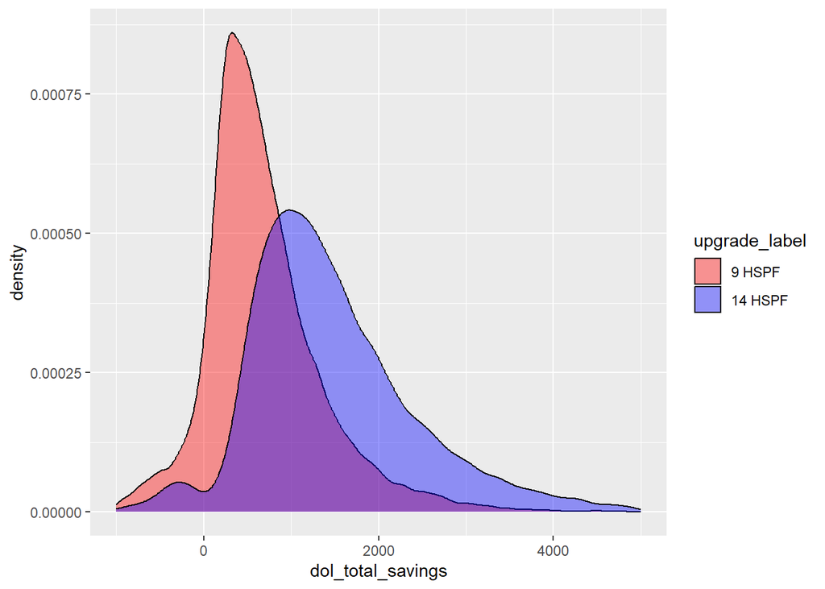

```r
ggplot(data = compare %>% filter(in.heating_fuel == 'Fuel Oil'),
       aes(x = dol_total_savings, fill = upgrade_label)) +
  geom_density(alpha = 0.4) +
  scale_fill_manual(values = c('9 HSPF' = 'red', '14 HSPF' = 'blue')) +
  xlim(c(-1000,5000))
```

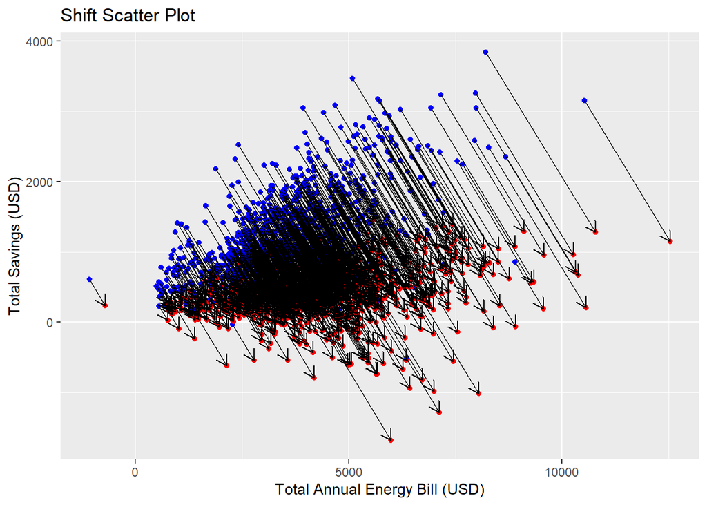

```r
plot11 <- compare %>% filter(in.state == 'CT', in.heating_fuel == 'Fuel Oil', upgrade == 11, in.sqft %in% c(1220,1690, 2176, 2663), in.hvac_cooling_type == 'Central AC')
plot12 <- compare %>% filter(in.state == 'CT', in.heating_fuel == 'Fuel Oil', upgrade == 12, in.sqft %in% c(1220,1690, 2176, 2663), in.hvac_cooling_type == 'Central AC')

ggplot() +
  geom_point(data = plot12, aes(x = dol_total, y = dol_total_savings), color = 'blue') +
  geom_point(data = plot11, aes(x = dol_total, y = dol_total_savings), color = 'red') +
  geom_segment(aes(x = plot12$dol_total, y = plot12$dol_total_savings,
                   xend = plot11$dol_total, yend = plot11$dol_total_savings),
               arrow = arrow(length = unit(0.3, "cm"))) +
  labs(title = "Shift Scatter Plot",
       x = "Total Annual Energy Bill (USD)",
       y = "Total Savings (USD)")
```

This is a little hard to see, but it’s clear that savings are impacted across homes. Here instead is a density plot showing distribution of the savings loss as a percent of savings under the 14 HSPF scenario (fuel oil CT homes only):

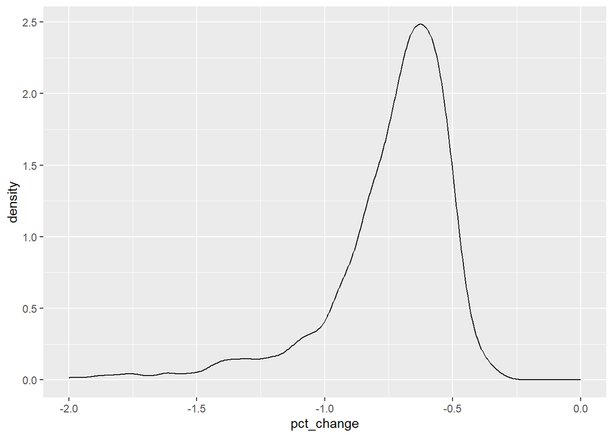

```r
savings_loss <- compare %>%
  filter(upgrade == 11) %>%
  left_join(compare %>% filter(upgrade == 12) %>% select(bldg_id, dol_total_savings, out.site_energy.net.energy_consumption.kwh) %>%
              rename(dol_total_savings12 = dol_total_savings,
                     out.site_energy.net.energy_consumption.kwh12 = out.site_energy.net.energy_consumption.kwh)) %>%
  mutate(pct_change = dol_total_savings / dol_total_savings12 - 1,
         dol_change = dol_total_savings - dol_total_savings12,
         kwh_change = out.site_energy.net.energy_consumption.kwh - out.site_energy.net.energy_consumption.kwh12)

ggplot(data = savings_loss %>% filter(in.state == 'CT', in.heating_fuel == 'Fuel Oil'), aes(x = pct_change)) +
  geom_density(alpha = 0.4) +
  xlim(c(-2,0))
```

It’s a pretty tight distribution of savings degradation. The ones that have larger losses in savings had lower savings to begin with. Most fuel oil homes in CT are losing something like 60%-70% of their savings by the shift from 14 HSPF to 9 HSPF.

I know that it’s not necessarily linear, but let’s assume that savings are linear with HSPF, at least from 9 HSPF to 14 HSPF. We’ll divide the change in dollar savings from 9 HSPF to 14 HSPF by 5, so that we can see approximately how much each HSPF point is worth in terms of dollar savings. And then we’re going to do a few cuts with that. To account for differences in heating fuel distribution in each region, we’re going to hold that constant and only look at natural gas since it’s prevalent in all regions.The below is a table showing per HSPF change in savings, and per HSPF change in kwh usage. For example, in Cold climates, each reduction in HSPF translates into an additional expense of $106 per year, and an additional 1,284 kwh of heating.

```r
savings_loss$dol_change_per_hspf <- savings_loss$dol_change / 5
savings_loss$kwh_change_per_hspf <- savings_loss$kwh_change / 5
savings_loss %>%
  filter(in.heating_fuel == 'Natural Gas') %>%
  group_by(in.building_america_climate_zone) %>%
  summarize(avg_dol_change_per_hspf = mean(dol_change_per_hspf),
            avg_kwh_change_per_hspf = mean(kwh_change_per_hspf))
```

| in.building_america_climate_zone | avg_dol_change_per_hspf | avg_kwh_change_per_hspf |
| --- | --- | --- |
| Cold | -106.92317 | 1284.9281 |
| Hot-Dry | -77.67241 | 444.4183 |
| Hot-Humid | -91.05782 | 774.5389 |
| Marine | -57.45447 | 446.5433 |
| Mixed-Dry | -78.23487 | 753.9602 |
| Mixed-Humid | -110.27909 | 1070.9916 |
| Very Cold | -91.74345 | 1322.0895 |

Cold climates have larger changes in savings per HSPF than warmer climates. This is partly due to differences in energy prices, and also due to differences in heating requirements (you can see kwh used go up dramatically with every loss in HSPF). One thing this brings up is the under-sizing of these units. The above increases in kwh reflect not only additional heat pump load, but also additional backup heating. We can get a sense of how much heat is being supplied by backup heating by looking the percent of thermal energy output provided by heat pump vs. backup system.

This gets a little more complicated to wrangle in the data because we only see input energy, not output energy in the home. But we can determine output thermal energy required by a home using the baseline scenario and then adjusting for the AFUE of the heating system. Then, we can determine what % of that heat is supplied by the backup system in both the 9 HSPF and 14 HSPF scenarios:

```r
up0 <- data_p2 %>%
  filter(upgrade == 0) %>%
  mutate(kwh_el_heating_output = replace_na(out.electricity.heating.energy_consumption.kwh + out.electricity.heating_fans_pumps.energy_consumption.kwh + out.electricity.heating_hp_bkup.energy_consumption.kwh,0),
         kwh_ng_heating_output = replace_na(out.natural_gas.heating.energy_consumption.kwh + out.natural_gas.heating_hp_bkup.energy_consumption.kwh,0) * heating_effic_def,
         kwh_fo_heating_output = replace_na(out.fuel_oil.heating.energy_consumption.kwh + out.fuel_oil.heating_hp_bkup.energy_consumption.kwh,0) * heating_effic_def,
         kwh_lp_heating_output = replace_na(out.propane.heating.energy_consumption.kwh + out.propane.heating_hp_bkup.energy_consumption.kwh,0) * heating_effic_def,
         kwh_total_heating_output_reqd = kwh_el_heating_output + kwh_ng_heating_output + kwh_fo_heating_output + kwh_lp_heating_output) %>%
  select(bldg_id, kwh_total_heating_output_reqd)

backup <- data_p2 %>%
  filter(upgrade %in% c(3,4)) %>%
  left_join(up0, by = 'bldg_id') %>%
  mutate(pct_bkup = replace_na((out.electricity.heating_hp_bkup.energy_consumption.kwh) / kwh_total_heating_output_reqd, 0)) %>%
  filter(!(kwh_total_heating_output_reqd == 0))

backup %>% group_by(in.heating_fuel, upgrade) %>%
  summarize(avg_pct_bkup = mean(pct_bkup)) %>%
  spread(upgrade,avg_pct_bkup) %>%
  rename('9 HSPF' = '3',
         '14 HSPF' = '4')
```

| in.heating_fuel | 9 HSPF | 14 HSPF |
| --- | --- | --- |
| Electricity | 0.08062787 | 0.02866694 |
| Fuel Oil | 0.23431248 | 0.11742956 |
| Natural Gas | 0.15749491 | 0.07484340 |
| Propane | 0.18917004 | 0.09417177 |

In the 9 HSPF scenario, a fair amount of energy is actually being supplied by the backup fuel (23%), which is detrimental to savings. Let’s look at CT specifically:

```r
backup %>%
  filter(in.state == 'CT') %>%
  group_by(in.heating_fuel, upgrade) %>%
  summarize(avg_pct_bkup = mean(pct_bkup)) %>%
  spread(upgrade,avg_pct_bkup) %>%
  rename('9 HSPF' = '3',
         '14 HSPF' = '4')
```

| in.heating_fuel | 9 HSPF | 14 HSPF |
| --- | --- | --- |
| Electricity | 0.2273119 | 0.1124894 |
| Fuel Oil | 0.2602692 | 0.1309678 |
| Natural Gas | 0.2493811 | 0.1237014 |
| Propane | 0.2658339 | 0.1300554 |

It looks like the use of backup heating is consistent across the state, regardless of heating fuel, which means that the backup heating requirements depend on the local climate (which obviously makes sense but helpful to see this in the data). Let’s look at the use of backup heating by climate zone:

```r
backup %>%
  group_by(in.building_america_climate_zone, upgrade) %>%
  summarize(avg_pct_bkup = mean(pct_bkup)) %>%
  spread(upgrade,avg_pct_bkup) %>%
  rename('9 HSPF' = '3',
         '14 HSPF' = '4')
```

| in.building_america_climate_zone | 9 HSPF | 14 HSPF |
| --- | --- | --- |
| Cold | 0.27088858 | 0.138924707 |
| Hot-Dry | 0.01006090 | 0.002926786 |
| Hot-Humid | 0.01038153 | 0.002279259 |
| Marine | 0.05508510 | 0.024020583 |
| Mixed-Dry | 0.11574574 | 0.043885615 |
| Mixed-Humid | 0.11221873 | 0.032873252 |
| Very Cold | 0.38954748 | 0.266760256 |

This makes sense - the colder the climate, the more backup heating is required. In warmer climates, a 9 HSPF heat pump will meet virtually all heating needs, whereas in Very Cold climates, 39% of heating needs are still met by backup with a 9 HSPF unit (and 27% even with a 14 HSPF unit). I’m not as familiar with the capacity of each of these HSPFs to heat in cold climates, but I suspect based on what we’ve discussed, that the units tend to be undersized for the home in this NREL analysis, thus requiring backup. For example, even with a very high efficiency 14 HSPF unit, 14% of heating needs in Cold climates still need to be met with backup, which I think goes against what we’ve seen and heard.

What’s a bit hard about disentangling all this is that there are two effects in the NREL analysis as HSPF goes down. One, the efficiency of the heat pump obviously decreases thereby lowering average COP, which is detrimental to savings. But two, the amount of heat that needs to be supplied by backup increases, which in the case of expensive fuel oil, is also detrimental to savings. I believe (although do not know this) that we feel more comfortable solving for (2) by properly sizing heat pump units for homes, such that even at 9 HSPF, most of the heating needs can be met by a heat pump. As a result, it would be good to disentangle these two effects.

Let’s look only at CT and only at fuel oil homes, for the sake of holding energy prices constant for now and keeping it simpler. Then, I want to look at heating energy by source (heat pump vs. backup) in the 9 HSPF and 14 HSPF scenario. We should decompose the increase in electricity required per HSPF into the increase in heat pump electricity (pure efficiency loss) and the increase in backup heating required.

```r
data_p6 %>%
  filter(in.state == 'CT', in.heating_fuel == 'Fuel Oil') %>%
  group_by(upgrade) %>%
  rename(fuel_oil_primary_heat = out.fuel_oil.heating.energy_consumption.kwh,
            fuel_oil_backup_heat = out.fuel_oil.heating_hp_bkup.energy_consumption.kwh,
            electricity_primary_heat = out.electricity.heating.energy_consumption.kwh,
            electricity_backup_heat = out.electricity.heating_hp_bkup.energy_consumption.kwh,
            electricity_fans = out.electricity.heating_fans_pumps.energy_consumption.kwh
  ) %>%
  summarize(fuel_oil_primary_heat = mean(fuel_oil_primary_heat),
            fuel_oil_backup_heat = mean(fuel_oil_backup_heat),
            electricity_primary_heat = mean(electricity_primary_heat),
            electricity_backup_heat = mean(electricity_backup_heat),
            electricity_fans = mean(electricity_fans))
```

| upgrade | fuel_oil_primary_heat | fuel_oil_backup_heat | electricity_primary_heat | electricity_backup_heat | electricity_fans |
| --- | --- | --- | --- | --- | --- |
| 0 | 31837.07 | 0.000 | 0.000 | 0.000 | 604.0568 |
| 3 | 0.00 | 0.000 | 6622.549 | 7342.735 | 355.4196 |
| 4 | 0.00 | 0.000 | 4710.840 | 3895.948 | 320.1743 |
| 11 | 0.00 | 9101.065 | 6622.549 | 0.000 | 355.4196 |
| 12 | 0.00 | 4828.253 | 4710.840 | 0.000 | 320.1743 |

The above represents the average CT fuel oil home. Let’s look at the differences between scenario 11 and 12, which represent 9 and 14 HSPF heat pump scenarios, respectively, both with fuel oil as backup. In the 9 HSPF scenario, 6,623 kwh of electricity were used for the heat pump (excluding fans for simplicity). In the 14 HSPF scenario, 4,711 kwh were used, so the difference is 1,912 kwh, or 382 kwh per HSPF point (dividing by 5). At approximately 20 cents per kwh, that’s an annual price difference of approximately $76. Now, let’s look at the increase in fuel oil for backup. That delta is 4,274 kwh, and diving by 5, we get 855 kwh per HSPF point. Converting into gallons (dividing by 1.3738 therms per gallon and then dividing that by 29.308 kwh per therm) gets us 21 gallons of incremental backup fuel oil. At something like $3.50 per gallon, we get a $74 dollar increase per HSPF point from additional fuel oil backup required. In other words, per 1 HSPF point, a home saves about $150 per year, half from improved efficiency of the heat pump, and half from less fuel oil backup heating.

It’s important to note that those two are not necessarily independent of one another. In other words, let’s say the NREL data was off on sizing, and we just needed to up the tonnage to compensate, but a lower HSPF was fine. That lower HSPF unit, at a higher tonnage, would then have a higher mix of cold temps where it’s active, which would reduce the blended average COP, and therefore the $76 per HSPF would actually be higher. Put simply, if we believe that increasing capacity could eliminate the $74 per HSPF cost of additional fuel oil backup, I think we probably also need to believe that the $76 per HSPF efficiency change could be higher.

Other stuff: AC type in CT:

```r
data_p6 %>% filter(upgrade == 0, in.state == 'CT',in.puma == 'G09000700') %>%
  group_by(in.hvac_cooling_type) %>%
  summarize(homes = n()*242) %>%
  mutate(total_homes = sum(homes),
         percentage = homes / total_homes) %>%
  select(-total_homes)
```

| in.hvac_cooling_type | homes | percentage |
| --- | --- | --- |
| Central AC | 29766 | 0.572093023 |
| Heat Pump | 484 | 0.009302326 |
| None | 8228 | 0.158139535 |
| Room AC | 13552 | 0.260465116 |